# BIOINF3005/7160: Transcriptomics Applications

Week 7.1: More Complex Designs

29<sup>th</sup> April 2020

# Introduction

## Recap

Before the mid-semester break, we looked at using a model matrix to analyse a transcriptomic dataset. The samples were used for this were $T_h$ cells which were either PI16<sup>+</sup> of PI16<sup>-</sup>, based on the detection of the PI16 protein on the cell surface. The paper this came from can be found [here](https://onlinelibrary.wiley.com/doi/abs/10.1002/eji.201948094).

Our metadata for this analysis had the following structure:

|  | array_id | cell_type | PI16 | donor |
| --- | --- | --- | --- | --- |
| **SB_Th-1** | SB_Th-1 | Th | - | 1 |
| **SB_Th+1** | SB_Th+1 | Th | + | 1 |
| **SB_Th-2** | SB_Th-2 | Th | - | 2 |
| **SB_Th+2** | SB_Th+2 | Th | + | 2 |
| **SB_Th-3** | SB_Th-3 | Th | - | 3 |
| **SB_Th+3** | SB_Th+3 | Th | + | 3 |
| **SB_Th-4** | SB_Th-4 | Th | - | 4 |
| **SB_Th+4** | SB_Th+4 | Th | + | 4 |

Note that we used the column `PI16` as a *categorical variable* with the reference level (i.e. 1<sup>st</sup> level) being defined as PI16<sup>-</sup> cells. We then formed a model matrix which set the reference level as the first column (i.e. the Intercept) and *the difference between cell types* defined as the second column.

## The Model Matrix

```r
X <- model.matrix(~PI16, data = pData(eset))
X
```

```
##         (Intercept) PI16+
## SB_Th-1           1     0
## SB_Th+1           1     1
## SB_Th-2           1     0
## SB_Th+2           1     1
## SB_Th-3           1     0
## SB_Th+3           1     1
## SB_Th-4           1     0
## SB_Th+4           1     1
## attr(,"assign")
## [1] 0 1
## attr(,"contrasts")
## attr(,"contrasts")$PI16
## [1] "contr.treatment"
```

A model matrix is how a statistical model calculates estimates associated with the predictor variable from each column of interest, i.e. the PI16 status. There is some linear algebra associated with this, which is technically beyond the scope of this course, but for those who are interested, a vector of coefficients for each gene ($\hat{\beta}$) is obtained using the Least Squares method. In the following, our model matrix is $X$, with a vector of expression estimates provided as $y$:

$$\hat{\beta} = (X^T X)^{-1} X^T y$$

For those who are really interested, we can demonstrate this using one of our DE genes `ENSG00000183813` (*CCR4*). To find the inverse of a matrix in R we use the function `solve()`, whilst to transpose it we use `t()`. Matrix multiplication is performed using `%*%`

First we can do it manually:

```r
y <- exprs(eset)["ENSG00000183813_at",]
beta_hat <- solve(t(X) %*% X) %*% t(X) %*% y
beta_hat[,1]
```

```
## (Intercept)       PI16+
##    8.289057    2.539037
```

Now compare to the limma version:

```r
fit <- lmFit(eset, design = X)
fit$coefficients["ENSG00000183813_at",]
```

```
## (Intercept)       PI16+
##    8.289057    2.539037
```

This structure provides a way of estimating a single gene’s expression level in each cell type, with the expression level in the reference (i.e. PI16<sup>-</sup>) cells estimated from the intercept, whilst **the expression in the second cell type** (i.e. PI16<sup>+</sup>) **is estimated using the sum of both values.** The convenience factor here is that we also have the *difference between the two cell types (logFC) as a direct estimate*. It’s good to know how these design matrices are actually used mathematically too. There’s a whole lot of 2<sup>nd</sup> year statistics in that section above, so don’t be too fazed if you haven’t seen that before. Hopefully it helps you understand why we have these design matrices though, and today we’ll move beyond a two-way comparison.

As well as introducing design matrices, we looked using `eBayes()` to moderate variances, introduced sample weights and explored an alternative approach to $H_0$ using `treat()`

# Preparation

## R Markdown

For today’s session, we’ll continue to look at the microarray dataset from last time, however we’ll now include the original four cell types, which includes not only $T_h$ cells, but also $T_{\text{reg}}$.

In order to set ourselves up for the day, **please ensure you are in your `~/transcriptomics` folder**, and using an **R Project called `practical_7` within that folder.** If you can’t find your way, then please ask for help.

Begin an R Markdown and tidy up the YAML header. Here’s an example YAML header (this is actually the YAML from this instruction page). Add your own name in the (currently missing) `author:` field if you’d like, and feel free to change or delete the title/subtitle.

```
---
title: "BIOINF3005/7160:<br>Transcriptomics Applications"
subtitle: "Week 7.1: More Complex Designs"
date: "29^th^ April 2020"
output:
  html_document:
    toc: yes
    toc_float: yes
---
```

After the header, add the usual `setup` chunk. Notice that I’ve added an extra line this time to ensure all figures are centre-aligned.

```r
knitr::opts_chunk$set(
    echo = TRUE,
    message = FALSE,
    warning = FALSE,
    fig.align = "center"
)
```

The libraries we’ll need for today are as follows, and we’ll discuss all of these as we come across them during the session.

```r
library(Biobase)
library(limma)
library(magrittr)
library(tidyverse)
library(pander)
theme_set(theme_bw())
```

## Today’s Data

The two subsets of this data have been pre-prepared as `ExpressionSet` objects and are available for direct import into your VM.

```r
Th <- url("https://github.com/UofABioinformaticsHub/transcriptomics_applications/raw/master/practicals/data/pi16_Th_eset.rds") %>%
    read_rds
Tr <- url("https://github.com/UofABioinformaticsHub/transcriptomics_applications/raw/master/practicals/data/pi16_Treg_eset.rds") %>%
    read_rds
```

To form our merged dataset, we can just use the function `combine()` which joins two datasets. However, we may need to explicitly call the version of this function from `Biobase`.

```r
eset <- Biobase::combine(Th, Tr)
```

Let’s see what we have in our combined metadata

```r
pData(eset)
```

Now we’re going to include a second categorical variable for the column `cell_type`, so let’s change that into a factor with $T_h$ as the baseline.

```r
pData(eset)$cell_type <- factor(pData(eset)$cell_type, levels = c("Th", "Treg"))
```

Finally, let’s add a group column where we combined the cell-type with the PI16 status. We can be lazy here and just let the function `as.factor()` determine the factors levels alpha-numerically.

```r
pData(eset) <- pData(eset) %>%
  mutate(
    group = case_when(
      PI16 == "+" ~ paste0(cell_type, "_PI16_plus"),
      PI16 == "-" ~ paste0(cell_type, "_PI16_minus")
    ),
    group = as.factor(group)
  )
```

Although these won’t show clearly up in a generic `data.frame` like we have here, we can use the function `glimpse()` to have a look at those factors, or `str()` for a more detailed look at the the structure.

```r
pData(eset) %>% glimpse()
pData(eset) %>% str()
```

# Using Contrasts

This complete dataset essentially gives us a square shaped design.

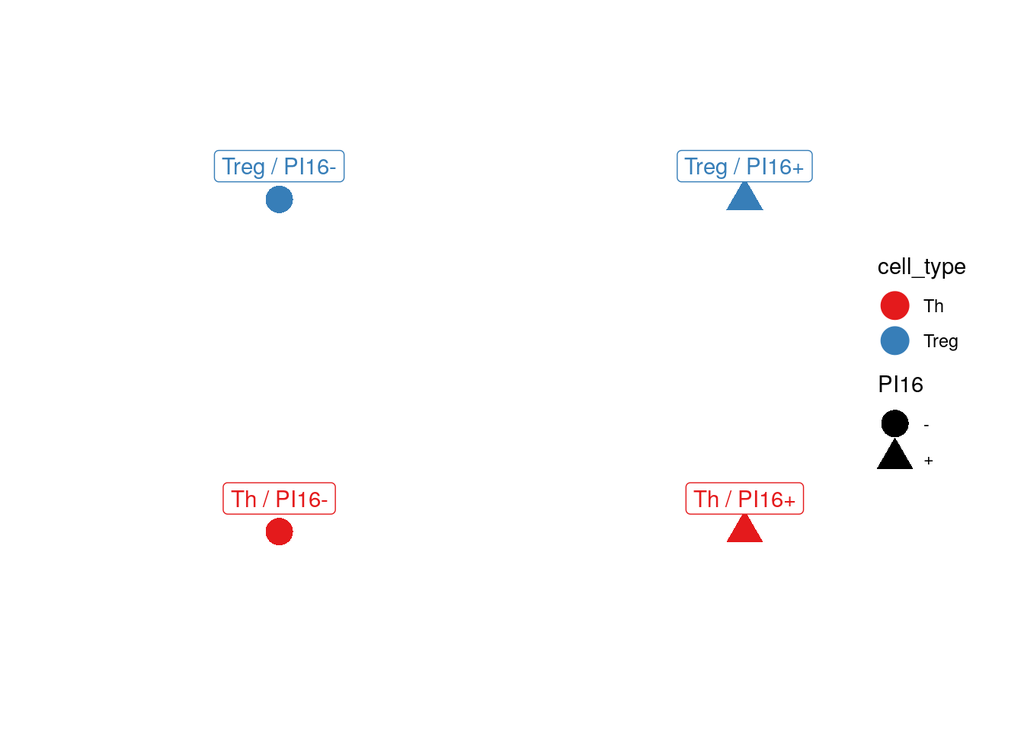

Some key questions we might like to ask of this data are:

1. What is commonly DE between PI16<sup>-</sup> and PI16<sup>+</sup> for both T<sub>reg</sub> & Th?
2. What is commonly DE between T<sub>reg</sub> & Th for both PI16<sup>+</sup> and PI16<sup>-</sup>?
3. Where do T<sub>reg</sub> and Th show unique changes between PI16<sup>-</sup> and PI16<sup>+</sup>?

## Genes Tracking with PI16 in Both Cell Types

The first question above seems intuitive and we can see this visually using arrows.

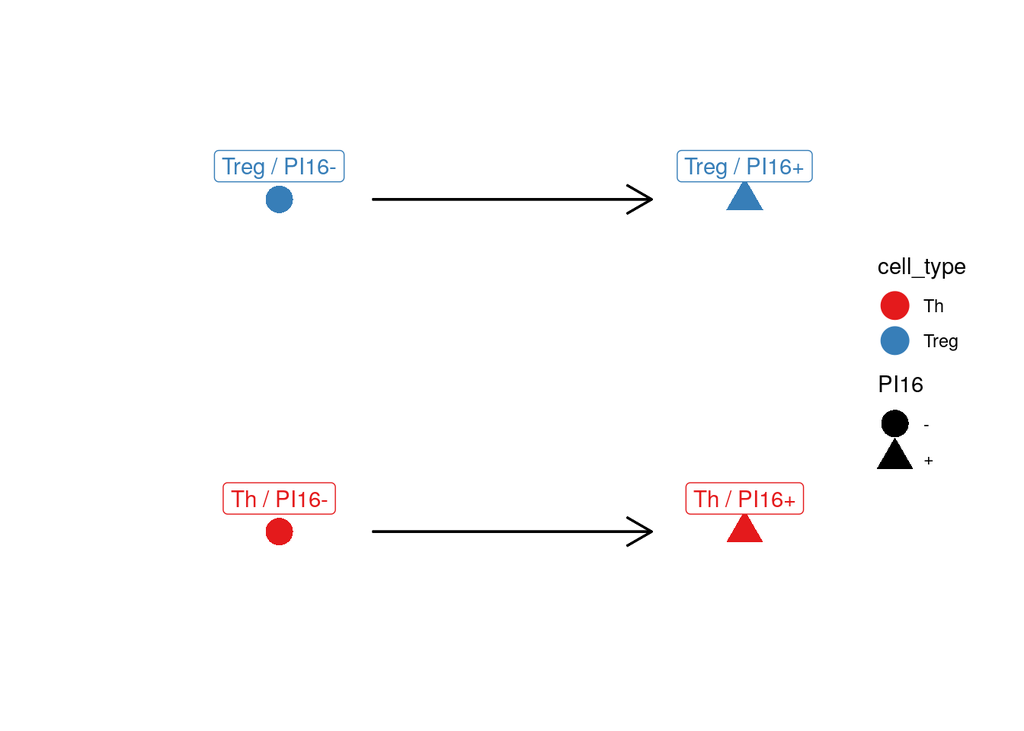

How would we find these genes? Would we perform two pair-wise comparisons and look for common genes? Would we set two intercepts and provide a design matrix?

### Pair-wise Comparisons

Let’s try the pair-wise comparisons approach first as that’s the easiest to understand. To do this, we should fit each cell type’s expression level without an intercept, then compare the ‘pairs’. Removing the Intercept from a model matrix would fit each group separately so at the end of this we would get an estimate of the average expression from each group.

```r
individual_design <- model.matrix(~ 0 + group, data = pData(eset)) %>%
  set_colnames(str_remove_all(colnames(.), "group"))
individual_design
```

In order to perform our pair-wise comparisons, we now use **contrasts** which are defined using the above column names and the function `makeCountrasts()`.

```r
cont_pairwise <- makeContrasts(
  tr_pi16 = Treg_PI16_plus - Treg_PI16_minus,
  th_pi16 = Th_PI16_plus - Th_PI16_minus,
  levels = colnames(individual_design)
)
cont_pairwise
```

We can now add this to our `lmFit()` output and obtain a `topTable` for each contrast.

```r
fit_pairwise <- lmFit(eset, design = individual_design) %>%
  contrasts.fit(cont_pairwise) %>%
  eBayes()
```

Let’s just look at the top few genes from each contrast. By default, the function `topTable()` will only return 10 genes, so let’s take advantage of that feature. Note that unlike the `limma` manual, I always specify contrasts using a character, not a number. This makes it far easier to read back, which is something we always need to keep in mind for our future selves and our collaborators.

```r
topTable(fit_pairwise, coef = "tr_pi16")
```

```r
topTable(fit_pairwise, coef = "th_pi16")
```

First let’s collect all of the results into a list with two tables. I find it can often be convenient to keep results in a list to save workspace clutter, and also to take advantage of a few tricks. I’m also going to add the contrast as a column.

```r
results_pairwise <- list(
  tr_pi16 = topTable(fit_pairwise, coef = "tr_pi16", number = Inf) %>%
    mutate(contrast = "tr_pi16"),
  th_pi16 = topTable(fit_pairwise, coef = "th_pi16", number = Inf) %>%
    mutate(contrast = "th_pi16")
)
```

Let’s check how many DE genes we get just using an FDR < 0.05. We can use `lapply()` to apply the same function to each element of this list. First we’ll apply a filter based on our FDR, then well count the DE genes by counting the rows. (This is why lists can be super handy)

```r
results_pairwise %>%
  lapply(dplyr::filter, adj.P.Val < 0.05) %>%
  lapply(nrow)
```

Let’s explore the data using volcano plots. You can do this any way you choose, but here’s my shortcut now we have a list.

```r
results_pairwise %>%
  bind_rows() %>%
  mutate(DE = adj.P.Val < 0.05) %>%
  ggplot(aes(logFC, -log10(P.Value), colour = DE)) +
  geom_point() +
  facet_wrap(~contrast, nrow = 1) +
  scale_colour_manual(values = c("black", "red"))
```

[output not shown]

```r
tests_pairwise <- decideTests(fit_pairwise)
summary(tests_pairwise)
vennDiagram(tests_pairwise)
```

[output not shown]

```r
results_pairwise %>%
  bind_rows() %>%
  as_tibble() %>%
  dplyr::select(
    gene_id, gene_name, logFC, AveExpr, P.Value, adj.P.Val, contrast
  ) %>%
  pivot_wider(
    id_cols = starts_with("gene"),
    names_from = contrast,
    values_from = c(logFC, P.Value, adj.P.Val)
  ) %>%
  ggplot(aes(logFC_tr_pi16, logFC_th_pi16)) +
  geom_point() +
  geom_abline(slope = 1, colour = "blue") +
  geom_vline(xintercept = c(-1, 1), linetype = 2, colour = "grey") +
  geom_hline(yintercept = c(-1, 1), linetype = 2, colour = "grey")
```

[output not shown]

We should see which genes are DE in each comparison as that will help us explore. We’ll just add an extra few lines to the above so we can remove the ‘never DE’ genes.

```r
results_pairwise %>%
  bind_rows() %>%
  as_tibble() %>%
  dplyr::select(
    gene_id, gene_name, logFC, AveExpr, P.Value, adj.P.Val, contrast
  ) %>%
  pivot_wider(
    id_cols = starts_with("gene"),
    names_from = contrast,
    values_from = c(logFC, P.Value, adj.P.Val)
  ) %>%
  mutate(
    DE = case_when(
      adj.P.Val_tr_pi16 < 0.05 &  adj.P.Val_th_pi16 < 0.05 ~ "Both",
      adj.P.Val_tr_pi16 >= 0.05 &  adj.P.Val_th_pi16 < 0.05 ~ "Th Only",
      adj.P.Val_tr_pi16 < 0.05 &  adj.P.Val_th_pi16 >= 0.05 ~ "Tr Only",
      adj.P.Val_tr_pi16 >= 0.05 &  adj.P.Val_th_pi16 >= 0.05 ~ "None",
    )
  ) %>%
  dplyr::filter(DE != "None") %>%
  ggplot(aes(logFC_tr_pi16, logFC_th_pi16, colour = DE)) +
  geom_point() +
  geom_abline(slope = 1) +
  geom_vline(xintercept = c(-1, 1), linetype = 2, colour = "grey") +
  geom_hline(yintercept = c(-1, 1), linetype = 2, colour = "grey")
```

[output not shown]

1. Would applying a logFC filter be wise?
2. Why do some genes show similar logFC in both comparisons, but only appear as DE in one.

Let’s quickly check the p-values before moving on. The code is essentially the same, so please cut and paste, making sure to just change the values for the x & y axes.

```r
results_pairwise %>%
  bind_rows() %>%
  as_tibble() %>%
  dplyr::select(
    gene_id, gene_name, logFC, AveExpr, P.Value, adj.P.Val, contrast
  ) %>%
  pivot_wider(
    id_cols = starts_with("gene"),
    names_from = contrast,
    values_from = c(logFC, P.Value, adj.P.Val)
  ) %>%
  mutate(
    DE = case_when(
      adj.P.Val_tr_pi16 < 0.05 &  adj.P.Val_th_pi16 < 0.05 ~ "Both",
      adj.P.Val_tr_pi16 >= 0.05 &  adj.P.Val_th_pi16 < 0.05 ~ "Th Only",
      adj.P.Val_tr_pi16 < 0.05 &  adj.P.Val_th_pi16 >= 0.05 ~ "Tr Only",
      adj.P.Val_tr_pi16 >= 0.05 &  adj.P.Val_th_pi16 >= 0.05 ~ "None",
    )
  ) %>%
  ggplot(aes(-log10(P.Value_tr_pi16), -log10(P.Value_th_pi16))) +
  geom_point(aes(colour = DE)) +
  geom_abline(slope = 1) +
  geom_smooth(se = FALSE)
```

[output not shown]

#### Outcomes

The above approach is commonly used, but one issue that we face is the use of hard cutoff values for either logFC and our FDR-adjusted p-values. A gene may be significant in one comparison, but have a p-value of 0.051 in another. Would that make it not differentially expressed in the second comparison?

We could spend ages working on this to find the common genes and understand this. We would undoubtedly find many interesting biological results for our collaborators, and they would likely be capturing genuine biology. Let’s move on though and look at an alternative.

### Fitting a Model Matrix

Instead of pair-wise comparisons, we’ll fit a common term for the presence of PI16 on the surface. Let’s create a new design matrix

```r
pi16_design <- model.matrix(~ 0 + cell_type + PI16, data = pData(eset))
pi16_design
```

Notice that in this design, we have effectively set two intercept terms but a column that captures any common PI16 effects. This is our column of interest, so when we fit these we don’t need a contrast matrix.

```r
fit_pi16 <- lmFit(eset, design = pi16_design) %>%
  eBayes()
topTable(fit_pi16, coef = "PI16+")
```

```r
results_pi16 <- topTable(fit_pi16, coef = "PI16+", number = Inf) %>%
  as_tibble()
```

Let’s see how many are significant just using an FDR of 0.05.

```r
sum(results_pi16$adj.P.Val < 0.05)
```

1. How does this compare to the previous results?
2. Would we need to apply a logFC filter.
3. Are there any expression patterns that we may miss using this approach?

## Interaction Terms

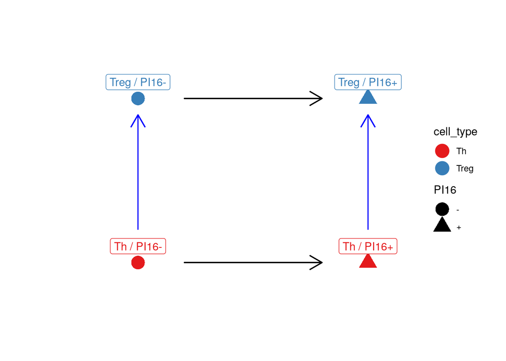

In the above we’ve only contemplated the effects of PI16 expression. This experiment also contains Tregs & Th, so we’d probably like to know where they’re different. A clear option would be pair-wise comparisons across the second axis, and this is what was published. Let’s explore an alternative approach though.

Imagine a gene was expressed at the same level in all groups, except for PI16<sup>+</sup> T<sub>reg</sub> where it becomes up-regulated. Would either of our above approaches capture this?

Let’s explore model matrix which sets the PI16- Th as the baseline (Intercept). In the second column we’ll fit the effects of being a T<sub>reg</sub>, whilst in the third we’ll fit the effects of being PI16<sup>+</sup>. Does this capture our hypothetical gene?

```r
model.matrix(~cell_type + PI16, data = pData(eset))
```

What we’ve really described in the above is the effects of being a PI16- T<sub>reg</sub> (column) and being a PI16<sup>+</sup> T<sub>h</sub>. To completely specify a model, we could include an interaction term as follows.

```r
model.matrix(~(cell_type + PI16)^2, data = pData(eset))
```

This specification would provide:

1. logFC estimates for being a PI16<sup>-</sup> T<sub>reg</sub> (column 1)
2. logFC estimates for being a PI16<sup>+</sup> T<sub>h</sub> (column 2)

The final column captures the final piece of the jigsaw but doesn’t quite have the same interpretation. This captures where the effects of being PI16<sup>+</sup> (col2) and being a T<sub>reg</sub> (col1) don’t explain the expression pattern.

Let’s look at a few examples.

### 1. No Significant Interaction term

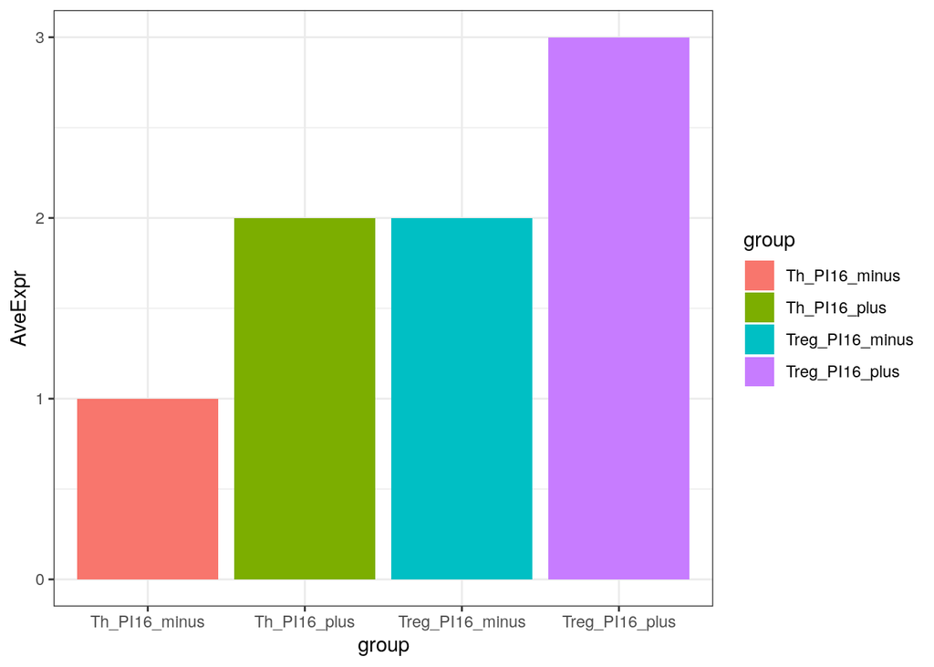

In the above, we would first fit the effect of being a PI16+ Th (logFC $\approx 1$) by comparing column 1 & 2. Next we would fit the effects of being a PI16- T<sub>reg</sub>, which is also a logFC of $\approx 1$. Therefore we would expect the expression in our PI16<sup>+</sup> T<sub>reg</sub> to be 3 (1 + 1 + 1). This is what we see, so the interaction term will be near zero & no significant term will result.

The effect of PI16 is to increase expression of the gene in both T<sub>reg</sub> & T<sub>h</sub>. Similarly, in the same PI16 group, the gene is consistently increased in T<sub>reg</sub> compared to T<sub>h</sub>.

### 2. A Significant Interaction term

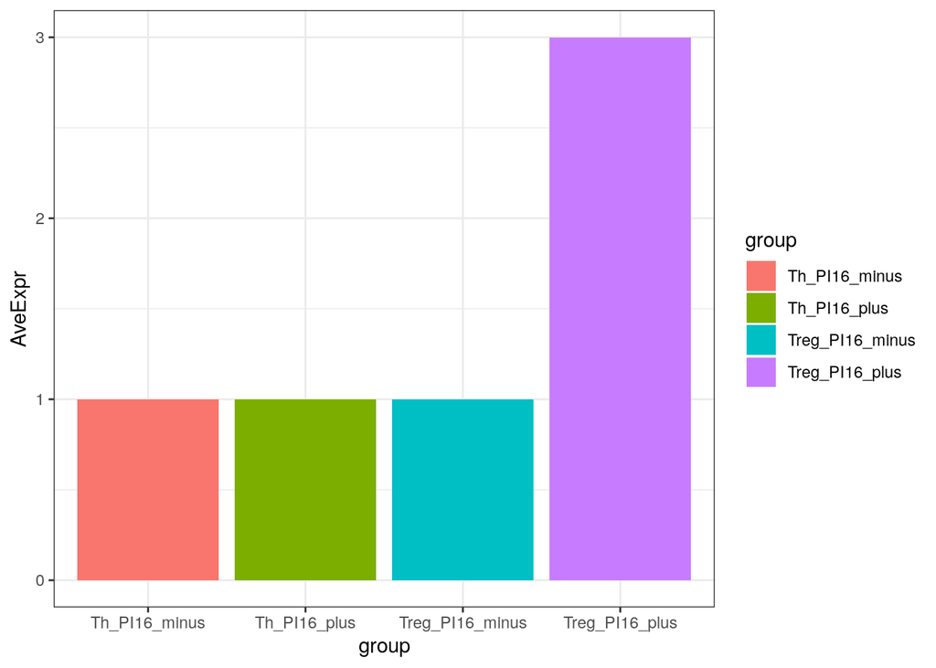

For this example, there is no difference between a) PI16<sup>+</sup> & PI16<sup>-</sup> T<sub>h</sub>; nor b) PI16<sup>-</sup> T<sub>h</sub> & T<sub>reg</sub>. However, in PI16<sup>+</sup> T<sub>reg</sub>, the gene goes up, so we would see a significant interaction term.

### 3. A Challenge

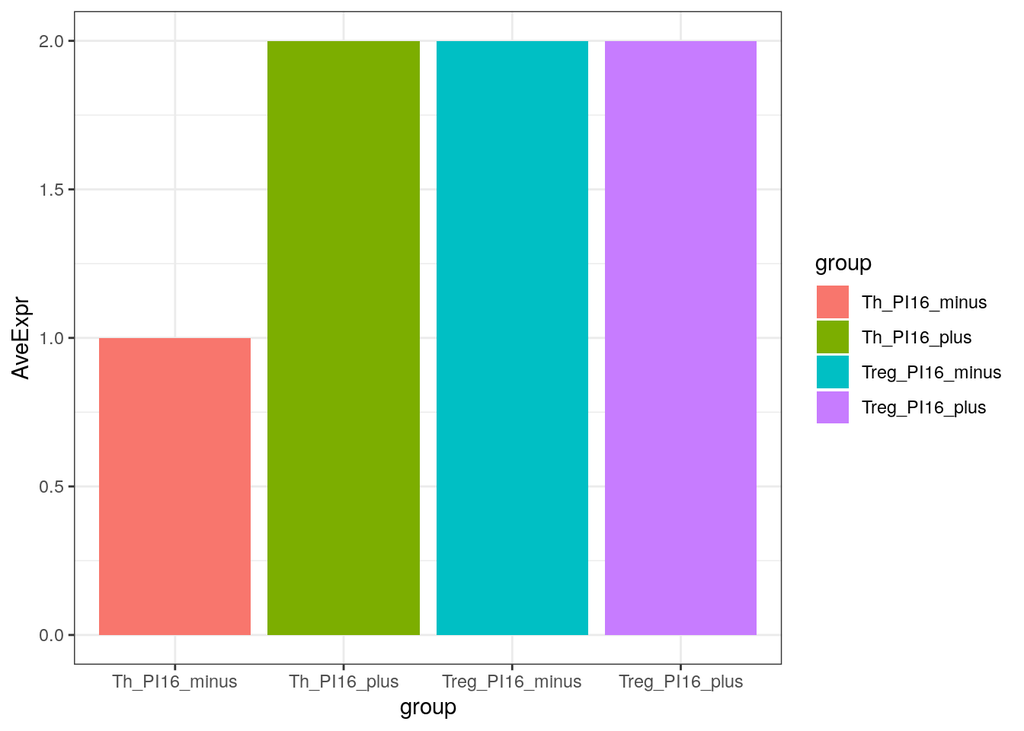

Would we see a significant interaction term here? How would we interpret this?